# HW1

### Permutation test for Kruskal-Wallis

$H_0$: Any observed difference among 3 Zones is due to **random label assignment**

$H_1$: The observed difference among 3 Zones is **statistically significant** and not due to chance.

```
##
## Based on permutation tests, There is a statistically significant difference between 3 Zones ( 0  < 0.01 ). in perm_test_svm
##
## Based on permutation tests, There is a statistically significant difference between 3 Zones ( 0  < 0.01 ). in perm_test_rf
##
## Based on permutation tests, There is a statistically significant difference between 3 Zones ( 0  < 0.01 ). in perm_test_logistic
```

### Distribution of U-Statistics

The **blue density** curves represent the distribution of **U-statistics** under the null hypothesis (randomly permuted labels).

The distributions are **centered around lower U-statistics** values, which suggests that the test statistics obtained from the random permutations are **significantly different** from the original U-statistics.

**Original U-Statistic** (**Red Dashed Line**):

In all three plots, the observed U-statistic is far to the right, outside the density distribution.

**p-value**:

The in all cases is 0, meaning that none of the permuted U-statistics reached or exceeded the original U-statistic.

**This indicates strong statistical significance**

The probability of obtaining the observed U-statistic under the null hypothesis is extremely low.

[figure not shown]

### Evaluate performance of each classifier (3 Zones)

We are going to use **Multi-Class ROC Curves (One vs. Rest)** for three different classification models: SVM, random forest and logistic regression.

| Model | Accuracy | AUC |
| --- | --- | --- |
| SVM | 0.1920481 | 0.3135208 |
| Random Forest | 0.1801933 | 0.3176269 |
| Logistic | 0.1738100 | 0.3120014 |

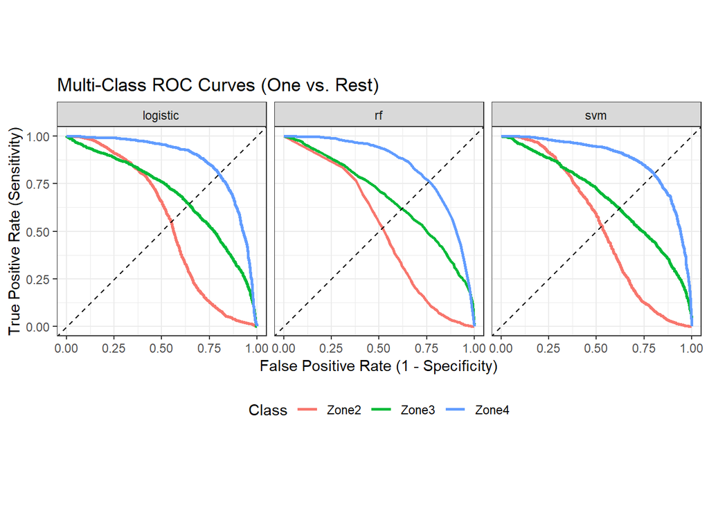

Moreover we can not rely on this method for multi-classes because of low performance over all classifiers.